# Coursera - Reproducible Research: Personal movement using activity monitoring devices

Load the required libraries

```r
library(ggplot2)
library(data.table)
```

Load the activity data from the provided URL

```r
if (!file.exists("activity.csv") )
{
fileurl = 'https://d396qusza40orc.cloudfront.net/repdata%2Fdata%2Factivity.zip'
download.file(fileurl,destfile = 'repdata_data_activity.zip',mode = 'wb')
unzip('repdata_data_activity.zip')
}
```

Read the data into a data.frame variable

```r
activitydata <- read.csv("activity.csv")
head(activitydata)
```

```
##   steps       date interval
## 1    NA 2012-10-01        0
## 2    NA 2012-10-01        5
## 3    NA 2012-10-01       10
## 4    NA 2012-10-01       15
## 5    NA 2012-10-01       20
## 6    NA 2012-10-01       25
```

# What is mean total number of steps taken per day?

### 1. Calculate the total number of steps taken per day

Remove NA’s from dataset

```r
activitydata_no_na <- activitydata[!is.na(activitydata$steps),]
head(activitydata_no_na)
```

```
##     steps       date interval
## 289     0 2012-10-02        0
## 290     0 2012-10-02        5
## 291     0 2012-10-02       10
## 292     0 2012-10-02       15
## 293     0 2012-10-02       20
## 294     0 2012-10-02       25
```

Number of steps taken each day

```r
total_steps_by_day <- aggregate(steps~date,activitydata_no_na,sum)
```

### 2. Histogram of the total number of steps taken each day

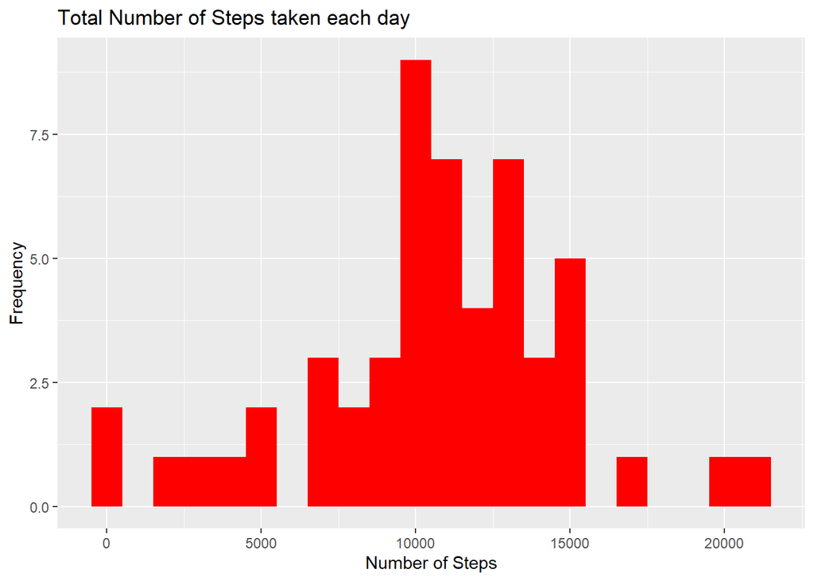

```r
ggplot(total_steps_by_day, aes(x = steps)) +
        geom_histogram(fill = "red", binwidth = 1000) +
        labs(title = "Total Number of Steps taken each day", x = "Number of Steps", y = "Frequency")
```

### 3. Calculate and report the mean and median total number of steps taken per day.

```r
mean_steps_per_day <- mean(total_steps_by_day$steps,na.rm=TRUE)
mean_steps_per_day
```

```
## [1] 10766.19
```

```r
median_steps_per_day <- median(total_steps_by_day$steps,na.rm = TRUE)
median_steps_per_day
```

```
## [1] 10765
```

# What is the average daily activity pattern?

### 1. Make a time series plot (i.e. type = “l”) of the 5-minute interval (x-axis) and the average number of steps taken, averaged across all days (y-axis)

```r
steps_by_interval <- aggregate(activitydata_no_na$steps,by=list(interval = activitydata_no_na$interval),FUN=mean)
names(steps_by_interval)[2] <- "steps"
head(steps_by_interval)
```

```
##   interval     steps
## 1        0 1.7169811
## 2        5 0.3396226
## 3       10 0.1320755
## 4       15 0.1509434
## 5       20 0.0754717
## 6       25 2.0943396
```

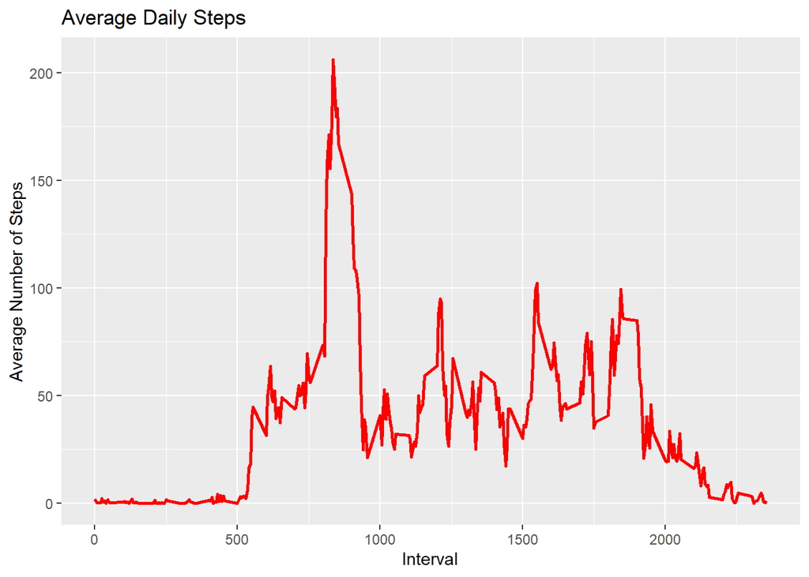

```r
ggplot(steps_by_interval,aes(x=interval,y=steps))+
        geom_line(color = "red",size=1)+
        labs(title="Average Daily Steps", x= "Interval", y ="Average Number of Steps")
```

### 2. Which 5-minute interval, on average across all the days in the dataset, contains the maximum number of steps?

```r
max_steps_interval <- steps_by_interval[which.max(steps_by_interval$steps),]
max_steps_interval
```

```
##     interval    steps
## 104      835 206.1698
```

# Imputing missing values

### 1. Calculate and report the total number of missing values in the dataset (i.e. the total number of rows with NAs)

```r
total_NAs <- sum(is.na(activitydata$steps))
total_NAs
```

```
## [1] 2304
```

### 2. Devise a strategy for filling in all of the missing values in the dataset. The strategy does not need to be sophisticated.For example, you could use the mean/median for that day, or the mean for that 5-minute interval, etc.

#### **To populate missing values, I prefer replacing NAs with the mean value at the same interval across days.**

### 3. Create a new dataset that is equal to the original dataset but with the missing data filled in.

Find the NA Values

```r
NA_location <- which(is.na((activitydata$steps)))
full_data <- activitydata
```

Imputing missing values using the mean for that 5-minute interval

```r
full_data[NA_location, ]$steps<-unlist(lapply(NA_location, FUN=function(NA_location){
        steps_by_interval[activitydata[NA_location,]$interval==steps_by_interval$interval,]$steps
}))
```

Check if the NA values were addressed. Output must show 0 with is.na

```r
head(full_data)
```

```
##       steps       date interval
## 1 1.7169811 2012-10-01        0
## 2 0.3396226 2012-10-01        5
## 3 0.1320755 2012-10-01       10
## 4 0.1509434 2012-10-01       15
## 5 0.0754717 2012-10-01       20
## 6 2.0943396 2012-10-01       25
```

```r
sum(is.na(full_data$steps))
```

```
## [1] 0
```

### 4. Make a histogram of the total number of steps taken each day and Calculate and report the mean and median total number of steps taken per day. Do these values differ from the estimates from the first part of the assignment? What is the impact of imputing missing data on the estimates of the total daily number of steps?

Create a data frame to capture total number of steps per day

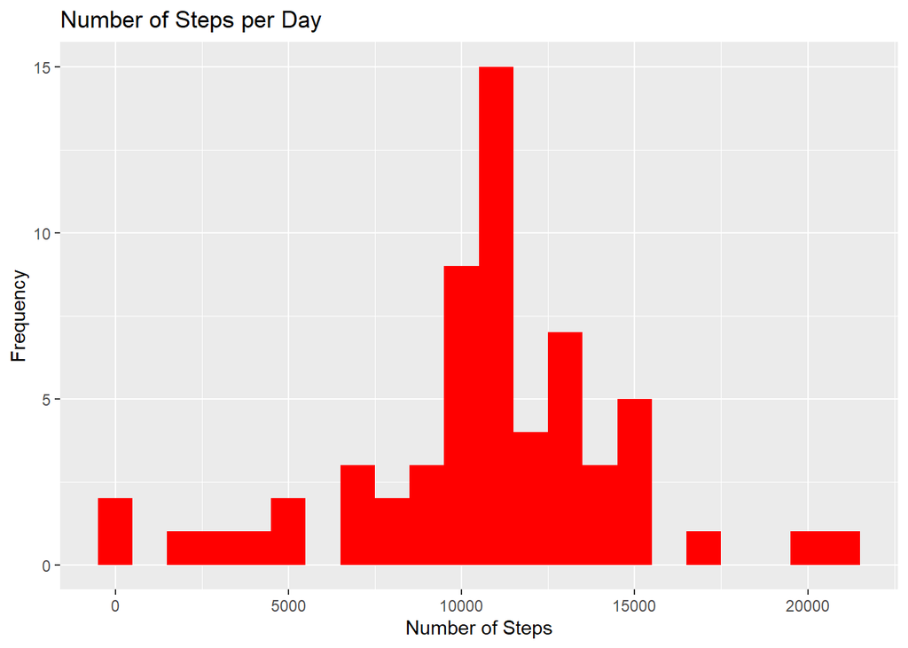

```r
tot_steps_per_day <- aggregate(steps~date, data = full_data,FUN = sum)
colnames(tot_steps_per_day) <- c("date", "steps")
ggplot(data = tot_steps_per_day, aes(x = steps))+
        geom_histogram(fill="red", binwidth = 1000)+
        labs(title = "Number of Steps per Day", x = "Number of Steps", y = "Frequency")
```

To check the impact of imputing the missing values, calculate the Mean and Median of steps taken each day

```r
tot_mean_steps_per_day <- mean(tot_steps_per_day$steps)
tot_mean_steps_per_day
```

```
## [1] 10766.19
```

```r
tot_median_steps_per_day <- median(tot_steps_per_day$steps)
tot_median_steps_per_day
```

```
## [1] 10766.19
```

#### **With imputing the missing values, I see the Mean and Median are both same which was not the case prior to imputing the missing values.**

# Are there differences in activity patterns between weekdays and weekends?

### 1. Create a new factor variable in the dataset with two levels – “weekday” and “weekend” indicating whether a given date is a weekday or weekend day.

```r
week_data <- data.table(full_data)
week_data[, weekident := ifelse(weekdays(as.Date(week_data$date)) %in% c("Saturday", "Sunday"), "Weekend", "Weekday")]
week_data$weekident <- as.factor(week_data$weekident)
head(week_data, 10)
```

```
##         steps       date interval weekident
##  1: 1.7169811 2012-10-01        0   Weekday
##  2: 0.3396226 2012-10-01        5   Weekday
##  3: 0.1320755 2012-10-01       10   Weekday
##  4: 0.1509434 2012-10-01       15   Weekday
##  5: 0.0754717 2012-10-01       20   Weekday
##  6: 2.0943396 2012-10-01       25   Weekday
##  7: 0.5283019 2012-10-01       30   Weekday
##  8: 0.8679245 2012-10-01       35   Weekday
##  9: 0.0000000 2012-10-01       40   Weekday
## 10: 1.4716981 2012-10-01       45   Weekday
```

### 2. Make a panel plot containing a time series plot (i.e. type = “l”) of the 5-minute interval (x-axis) and the average number of steps taken, averaged across all weekday days or weekend days (y-axis). See the README file in the GitHub repository to see an example of what this plot should look like using simulated data.

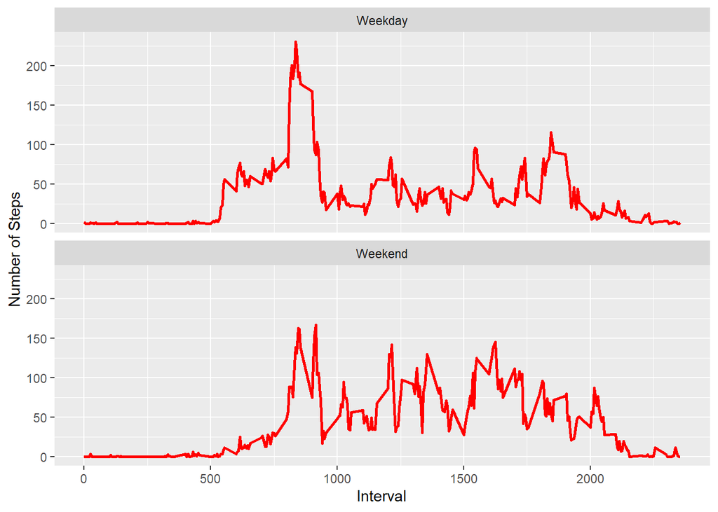

```r
steps_per_weekidentifier <- aggregate(steps ~ interval+weekident, data = week_data, FUN = mean)
ggplot(steps_per_weekidentifier, aes(x = interval, y = steps)) +
        geom_line(col = "red", size = 1) +
        facet_wrap(~ weekident, nrow=2, ncol=1) +
        labs(x = "Interval", y = "Number of Steps")
```

#### **By looking at the above graphs, I see one major activity during weekdays but more peaks during weekend. It looks like the person from whom data was collected was more active during weekends than week days.**